# Implementation Notes for Final

```python
import pandas as pd
import matplotlib.pyplot as plt
import seaborn as sns
import numpy as np
import math

# Just some color options for seaborn plots
sns.set(style="darkgrid")
sns.set_palette("Dark2")
```

## Two-Layer Model

In the equations below, I'm going to write everything in matrix notation. This is the quickest and cleanest way to write the equations for translating into Python code. The dimensions are as follows:

- $n$: number of data points
- $d$: number of features in the input data
- $m$: number of units in the hidden layer ($z$)

**First layer:** $$Z = \phi\left( X W^{(1)} \right)$$

- Your inputs are in a data matrix $X$, which is $n \times (d + 1)$. Assumes you concatenated a column of ones.
- Your weight matrix $W^{(1)}$ will be $(d + 1) \times m$.
- The $Z$ variables form a matrix of $n \times m$.
- Your activation function will either be logistic, $\phi(t) = \sigma(t)$, or ReLU, $\phi(t) = r(t)$. The notation above means to apply $\phi$ (a single-variable function) to each entry in the input matrix. See the next section for details on these two activation functions.

**Second layer:** $$\hat{y} = \sigma\left( Z W^{(2)} \right)$$

- Your $Z$ variables are the same as above **except** with an additional concatenation of a column of ones (so, now an $n \times (m + 1)$ matrix).
- Your weights $W^{(2)}$ are an $(m + 1)$-dimensional vector.
- Your output $\hat{y}$ is a vector of length $n$.
- **Note:** Your $z$ outputs from the first layer will need to be augmented with a 1 for the intercept.

You will need to implement two functions, `layer1(X, W1)` and `layer2(Z, W2)`, that compute the above two equations. The full "feed forward" of the network will compose these two functions. That is, `layer2(layer1(X, W1), W2)` will take you all the way from inputs ($X$) to outputs ($\hat{y}$).

**TIP:** Print out the shapes of all of your objects ($Z, X, \hat{y}, W$'s) to make sure they are correct!

## Activation Functions

Here is a review of the two activation functions, and their derivatives, that you will need. I'm also including some Python for them with plots to remind you what they look like.

### Logistic Activation

$$\sigma(t) = \frac{1}{1 + \exp(-t)}$$

$$\sigma'(t) = \frac{\exp(-t)}{(1 + \exp(-t))^2}$$

### Rectified Linear Unit (ReLU) Activation

$$r(t) = \max(0, t)$$

$$r'(t) = \begin{cases} 0 & \text{if $t \leq 0$} \\ 1 & \text{if $t > 0$} \end{cases}$$

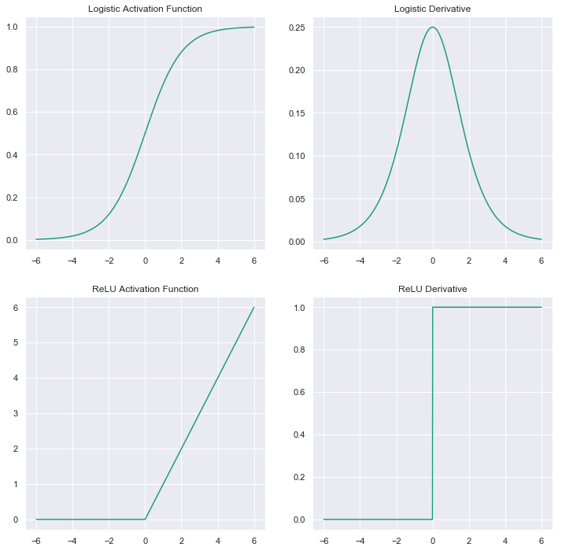

```python
def sigmoid(t):
    return 1 / (1 + np.exp(-t))

def dsigmoid(t):
    return np.exp(-t) / (1 + np.exp(-t))**2

def relu(t):
    return np.maximum(0, t)

def drelu(t):
    return np.clip(np.sign(t), a_min = 0, a_max = None)

t = np.linspace(-6, 6, 1000)
fig, ax = plt.subplots(2, 2, figsize=(12,12))
ax[0,0].plot(t, sigmoid(t))
ax[0,0].set_title("Logistic Activation Function")
ax[0,1].plot(t, dsigmoid(t))
ax[0,1].set_title("Logistic Derivative")
ax[1,0].plot(t, relu(t))
ax[1,0].set_title("ReLU Activation Function")
ax[1,1].plot(t, drelu(t))
ax[1,1].set_title("ReLU Derivative")
plt.show()
```

## Gradient Ascent Algorithm

Just like the logistic regression assignment, we are going to maximize log-likelihood. (Or, equivalently, we are going to minimize the cross-entropy loss, which is equal to the negative of the log-likelihood.) The difference now is that we have **two** sets of weights to optimize over, one for each layer. The good news is that the second layer weights, $W^{(2)}$, have the exact same gradient as the $\beta$ in logistic regression. The only thing new is the gradient for the first layer weights, $W^{(1)}$. I do recommend including a factor of $1 / n$ in the log-likelihood to scale down the numbers so that computations don't get overly large.

### Goal:

$$\max_{W^{(1)}, W^{(2)}} \, \ell\left(\hat{y}, y \right) = \max_{W^{(1)}, W^{(2)}} \, -\mathcal{L}(\hat{y}, y),$$

where the **log-likelihood** is this: $$\ell \left( \hat{y}, y \right) = \frac{1}{n} \sum_{i=1}^n y_i \ln (\hat{y}_i) + (1 - y_i) \ln (1 - \hat{y}_i).$$

This is equivalent to the equation we implemented in HW 5 for logistic regression. In matrix notation, this was:

$$\ell \left(\hat{y}, y\right) = \frac{1}{n} \left\langle (y - 1), Z W^{(2)} \right\rangle - \frac{1}{n} \sum_{i=1}^n \ln\left(1 + \exp \left(-Z W^{(2)}\right)\right)$$

**Note:** This takes $Z$, the hidden units, as input (as contrasted to logistic regression, which took $X$). So, you will have to call your `layer1` function to generate the $Z$ to pass to the log-likelihood. But you can use your previous code (or the code I gave you) for this `logLikelihood` function.

### Gradient with respect to $W^{(2)}$

This is the same function we implemented for the gradient of $\beta$ in logistic regression. I'm calling this `grad2` in the algorithm below. Again, use your previous code (or mine)! Just replace the inputs $X$ with $Z$ and $\beta$ with $W^{(2)}$. In matrix notation, this is:

$$\nabla_{W^{(2)}} \, \ell = \frac{1}{n} \left[(y - 1) + \frac{\exp\left(-Z W^{(2)}\right)}{1 + \exp\left(-Z W^{(2)}\right)}\right] Z$$

### Gradient with respect to $W^{(1)}$

This is the trickiest step to implement. I'm calling this `grad1` in the algorithm below. Remember this is where you need to compute a chain rule:

$$\left[ \nabla_{W^{(1)}} \, \ell \right]_{ij} = \sum_{k=1}^n \sum_{l=1}^m \left[ \nabla_Z \, \ell \right]_{kl} \frac{dZ_{kl}}{dW_{ij}}$$

1. The first term is this: $$\nabla_Z \, \ell = \frac{1}{n} \left[(y - 1) + \frac{\exp\left(-Z W^{(2)}\right)}{1 + \exp\left(-Z W^{(2)}\right)}\right] W^{(2)T}.$$ **Note:** the square brackets term is the same $n \times 1$ vector as in the previous gradient equation. The $W^{(2)T}$ term is the second weight vector **transposed**, that is, $1 \times m$. So, this entire term will be an $n \times m$ matrix.
   **Note 2:** The $W^{(2)}$ in this equation is **without** the intercept term, so it is $m$ dimensional, not $m+1$ dimensional.
2. The second term is this: $$\frac{d Z_{kl}}{d W^{(1)}_{ij}} = \left[ \phi'\left(X W^{(1)}\right) \right]_{kl} D_{ij} g_{kl}.$$ $$D_{ij} g_{kl} = \begin{cases} X_{ki} & \text{if $l = j$}\\ 0 & \text{if $l \neq j$}\end{cases}$$ **Note:** $\phi'\left(X W^{(1)}\right)$ means to apply the function $\phi'$ to every element of the matrix $X W^{(1)}$. The result is a $n \times m$ matrix.

### Simplified $W^{(1)}$ gradient!

The above gradient equations seem complicated and have a lot of indices $(i,j,k,l)$. A straight translation into code would involve a lot of loops. But you can do this all in Python without using any loops! I'm going to rewrite all of these equations using matrix operations that translate into just a few lines of Python code.

Start by expanding all of the terms in the $W^{(1)}$ gradient. We can use the fact that $l = j$ in the $D_{ij} g_{kl}$ term, so the sum over $l$ is all zeroed out, except for the single term where $l = j$. $$ \begin{aligned} \left[ \nabla_{W^{(1)}} \, \ell \right]_{ij} &= \sum_{k=1}^n \left[ \nabla_Z \, \ell \right]_{kj} \frac{dZ_{kj}}{dW_{ij}}\\ &= \sum_{k=1}^n \left[ \nabla_Z \, \ell \right]_{kj} \left[ \phi'\left(X W^{(1)}\right) \right]_{kj} X_{ki}\\ \end{aligned} $$

Now, handling this $k$ index is the tricky part. The sum almost looks like a matrix multiplication of the second and third terms -- but there is the first term also with a $k$ index messing that up! To handle this, let's define the following operation between a $d_1 \times d_2$ matrix $A$ and a $d_1 \times d_2$ matrix $B$:

$$A \star B = \begin{pmatrix} A_{11} B_{11} & A_{12} B_{12} & \cdots & A_{1d_2} B_{1d_2}\\ A_{21} B_{21} & A_{22} B_{22} & \cdot & A_{2d_2} B_{2d_2}\\ \vdots & \vdots & & \vdots\\ A_{d_1 1} B_{d_1 1} & A_{d_1 2} B_{d_1 2} & \cdots & A_{d_1 d_2} B_{d_1 d_2}\end{pmatrix}$$

Notice what this is doing: each entry of $A$ is multiplied element-by-element by the corresponding entries of $B$. In code, you can use the multiply operator (yes, just `*` this time!) to multiply the $A$ and $B$ matrix element-by-element.

**Final Equation:** Putting this all together, the matrix version of the gradient equation looks like the following (no indices!):

$$ \nabla_{W^{(1)}} \, \ell = X^T \left( \left[ \nabla_Z \, \ell \right] \star \phi'\left(X W^{(1)} \right) \right)$$

When you implment this, again be **very careful that the dimensions of your matrices** are coming out correctly (print out their shape as you are debugging). The terms about have the following dimensions:

$$ \begin{aligned} \nabla_{W^{(1)}} \, \ell & : (d + 1) \times m \\ X^T & : (d + 1) \times n\\ \nabla_Z \, \ell & : n \times m\\ \phi'\left(X W^{(1)} \right) & : n \times m \end{aligned} $$

## Pseudo-code for Gradient Ascent Loop

Putting the whole thing together, you will have the following algorithm for gradient ascent. (Here I am assuming that `X` has a column of ones already.)

```
while iter < maxIter:
    Z = layer1(X, W1)
    Z = Z concatenated with ones column
    save logLikelihood(W2, Z, y) for monitoring

    grad2 = gradW2(W2, Z, y)
    W2 = W2 + delta2 * grad2

    grad1 = gradW1(W1, W2, X, y)
    W1 = W1 + delta1 * grad1
```

Note: I've used two step sizes `delta1` and `delta2` to be most flexible, but you could try a single step size for both sets of weights and see if that works first. Also, for simplicity, I've just made the loop terminate after a maximum number of iterations, rather than see if both gradients fall below some $\epsilon$ threshold. Again, this is fine as long as you plot your log-likelihood and confirm it is converging.